# Code Quality Assurance (CQA)

Defence Statistics (Air)

Contact: Zoë Slade, zoe.slade100@mod.gov.uk

13 September, 2021

# 1 Introduction

This document contains tools and techniques for the quality assurance of R code within the Git workflow.

# 2 Code Style

> “Good coding style is like correct punctuation: you can manage without it, butitsuremakesthingseasiertoread”

Poorly styled code can be difficult for others to understand leading to frustration and time wasted on comprehension, and some stylistic errors such as missing brackets can cause erroneous outputs or even stop code running altogether.

Coding style covers a wide range of topics including naming conventions, syntax, file organisation and code structure. There is no single best way to style code and there are various style guides in existence, but it is important to use a consistent style whether this be across a project, team or department.

Helpfully there are various tools for R to support good code styling. Linters and formatters are two examples.

## 2.1 Linters

**Linters analyse code and flag stylistic errors.** The `lintr` package contains various linters, for example `lint()` to lint a file and `lint_package()` for a package.

Here is an example of some poorly styled code:

```r
# Use assignment operator, not equals sign
x = 2

# Always put a space after a comma, never before
x[,1]
x[ ,1]
x[ , 1]

# Avoid lines of code more than 80 characters long
my_data <- some_data %>% filter(some_value > 50, another_value == 5) %>% mutate(new_value = some_value/another_value)

# Do not put spaces inside or outside parentheses for regular function calls
mean (x, na.rm = TRUE)
mean( x, na.rm = TRUE )
```

Running `lint("file_name.R")` on the code automatically opens the ‘Markers’ pane in RStudio which diplays a list of stylist errors found by the linter:

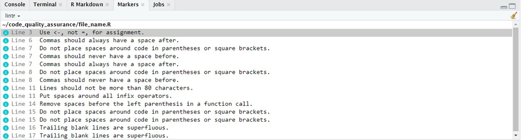

Note that you might need to install the `lintr` package before you can run `lint()`. Once installed, you will also be able to access `lintr` functions from RStudio’s Addins dropdown menu.

## 2.2 Formatters

**Formatters both detect and correct stylistic errors.** Common R formatters can be found in the `styler` package. By default `styler` conforms to [The Tidyverse Style Guide](https://style.tidyverse.org/), but settings are customizable.

All `styler` functions except `style_text()` automatically modify source code without creating a backup copy. It is therefore advisable to use version control in conjunction with `styler` to mitigate the risk of unintentionally overwriting code. It might also be a good idea to run a linter on your code first to view and understand stylistic errors before making changes with a formatter.

Running `style_file("file_name.R")` on the example code above automatically corrects the style errors and changes the script to

```r
# Resulting code from running styler

# Use assignment operator, not equals sign
x <- 2

# Always put a space after a comma, never before
x[, 1]
x[, 1]
x[, 1]

# Avoid lines of code more than 80 characters long
my_data <- some_data %>%
  filter(some_value > 50, another_value == 5) %>%
  mutate(new_value = some_value / another_value)

# Do not put spaces inside or outside parentheses for regular function calls
mean(x, na.rm = TRUE)
mean(x, na.rm = TRUE)
```

A message like this is displayed to the console to notify you that the file has been changed.

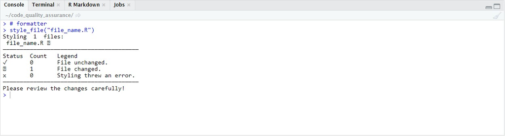

If `styler` finds an error that prevents the code parsing you will need to correct it before the code will be automatically styled.

Other functions within the `styler` package include `style_dir()` which styles all .R and/or .Rmd files in a directory and `style_pkg()` which styles the source files of an R package. Styler comes pre-loaded as an RStudio add-in which you can alternatively access from the Addin dropdown menu. For `styler`’s configuration options see here.

# 3 Git Hooks

Git hooks are tests that can be run locally at specific points in your Git workflow. For example, you might want to run tests to check whether scripts meet certain standards before integrating with a remote repository. Coding standards are likely to include code style and therefore `styler` and `linter` play a natural role in Git hooks within R.

Two commonly used hooks are pre-commit and pre-push hooks. If the tests pass, the commit/push will be made, otherwise it will not.

*In the process of being set up on MOD’s systems*

## 3.1 Pre-Commit Hooks

To set up pre-commit hooks, you first need to intall the `precommit` package:

```r
install.packages("precommit")
```

Then install the [pre-commit framework](https://pre-commit.com/) from pip by typing the following into the terminal:

```r
$ pip3 install pre-commit --user
```

Finally, run

```r
precommit::use_precommit()
```

This last call initializes pre-commit in your Git project and performs some set-up tasks like creating the config file `.pre-commit-config.yaml`.

The yaml file specifies the hooks (the tests) that will be run when you next attempt a `git commit`. It comes with pre-loaded defaults but is completely customizable. You can quickly open the yaml file via the helper function `precommit::open_config()`.

A commit will fail any time a file is changed due to running a hook or if a hook throws an error. The styler hook is an example of a hook that changes files and following a commit attempt with a styler hook initialized you will see an error message like this stating that the hook failed to pass and that a change has been made:

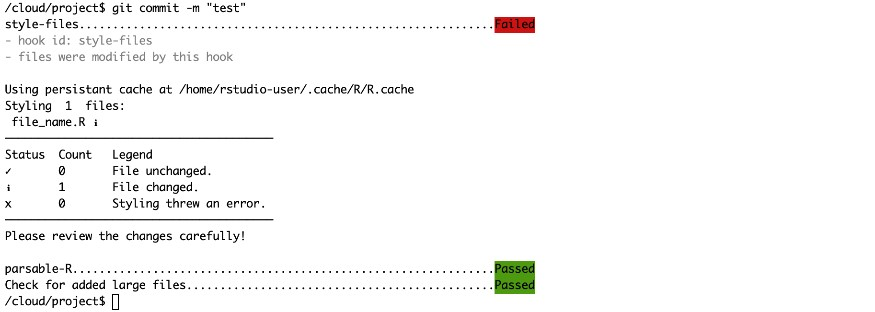

All you need to do in this case is inspect the changes and, if you are happy with them, stage the updated file ready to try the commit again (`$ git add path/to/file.R` in the terminal pane). (Note that the messages in the form above come from using `$ git commit` in the terminal but similar messaging will appear in the commit pop-up window if using RStudio’s IDE menus.)

Other hooks require you to go into a file and make changes yourself. For example, the `parasable-R` hook will fail if there’s a missing closing bracket and you will need to correct this before the hook will pass. Once all hooks pass, the commit is made and you will see something like this:

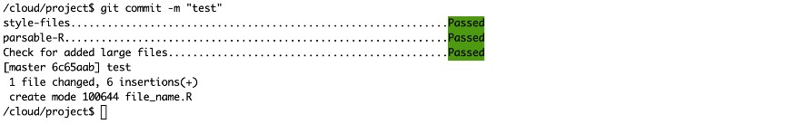

You can also [temporarily disable hooks](https://pre-commit.com/#temporarily-disabling-hooks). Further information can be found in the [pre-commit framework](https://pre-commit.com/) documentation.

## 3.2 Pre-Push Hooks

*To be completed…*

# 4 Code Review

Automated quality assurance tests using linters and formatters to vet code are incredibly useful but the great human ability to spot and correct mistakes should not be overlooked. This where code review comes in.

**What is code review?**  
Code review is the act of consciously and systematically convening with your fellow programmers to check each other’s code for mistakes.

**Why code review?**  
Code review is a great way of catching bugs that might slip through testing and therefore can save time for quality assurance teams downstream. In addition, code reviews foster communication in teams, create a sense of shared ownership of scripts and help less experienced coders understand better ways to write code or gain knowledge of useful shortcuts to troubleshoot common problems.

**How to code review?**  
Code reviews don’t have to be (and often aren’t) long formal processes. Below are some common lightweight approaches compatible with agile ways of working.

Over-the-shoulder  
Once your code is ready, find a colleague to sit down at your computer to peer review, with you on-hand to explain why you wrote your code the way you did. This approach can be adapted for remote working by sharing a screen over Skype or Teams. Document or track suggested changes as you go.

Pair programming  
Pair programming is when two people work on the same piece of code together thereby checking each other’s work as they go. This method has the advantage of baking code review into development. However, it can suffer from people being too close to their own code to review objectively and also people might not feel comfortable or be as effective coding in this way.

Tool assisted  
Software based code review tools offer the ability to easily track comments and suggested changes from colleagues (like tracking changes in MS word), allow reviews to happen non-locally and at any time, and notify the code author when the review is finished. These tools come with many advantages but might be overkill for small projects (or might not be possible if you don’t have access to the necessary software).

The email thread  
As soon as code is ready for review, a code file or link to the code is sent to colleagues to review at their earliest convenience. Whilst allowing for flexibility, it can be hard to keep track of feedback in email threads, especially if involving multiple colleagues.

## 4.1 Good Practice

- Keep review stints to under 60 minutes as concentration and ability to find bugs drops off after this time
- Try to keep reviews to under 200 to 400 lines of code at a time as beyond 400 the brain’s ability to find errors diminishes
- Decide on a method to capture feedback prior to review
- Use checklists (like the one below)
- Keep inspection rate to under 300-500 lines of code per hour and take regular 20-minute breaks
- Set goals (e.g., reduce runtime) and capture metrics (e.g., defect discovery rate)
- Establish a process for fixing defects found and verifying that they are actually fixed
- Foster a positive code review culture. Code reviews are a team building activity and provide an opportunity to learn; they should not be used to evaluate peoples’ performance

## 4.2 Code Review Checklist

- Does the script run without error?
- Is code sufficiently commented?
- Are comments clear and concise?
- Is code formatted logically?
- Is formatting consistent across scripts?
- Is code futureproof?

# 5 Unit Testing

*To be completed…*

# 6 Tidy Data

*To be completed…*

# 7 Addtional: Python

*To be completed…*  
There are also linters and formatters available in Python: pylint and Black.